# aed

```python
# Se repite el proceso para las festividades del año 2026
dataset_reconstruido: pd.DataFrame = dataset_reconstruido.merge(
    festivos_2026[[
        "Días",
        "¿Se debería considerar festivo?",
        "¿Se debería haber abierto?"
    ]],
    left_on="fecha",
    right_on="Días",
    how="left"
)

dataset_reconstruido.loc[
    dataset_reconstruido["¿Se debería considerar festivo?"].notna(),
    "bolHoliday_reconstruido"
] = (
    dataset_reconstruido.loc[
        dataset_reconstruido["¿Se debería considerar festivo?"].notna(),
        "¿Se debería considerar festivo?"
    ]
)

dataset_reconstruido.loc[
    dataset_reconstruido["¿Se debería haber abierto?"].notna(),
    "bolOpen_reconstruido"
] = (
    dataset_reconstruido.loc[
        dataset_reconstruido["¿Se debería haber abierto?"].notna(),
        "¿Se debería haber abierto?"
    ]
)

# Se eliminan los campos del DataFrame festivos_2026
dataset_reconstruido.drop(columns=[
    "Días",
    "¿Se debería considerar festivo?",
    "¿Se debería haber abierto?"
], inplace=True)
```

```python
# Se marcan como festivos todos los domingos del dataset excepto los de la última semana de junio
dataset_reconstruido.loc[dataset_reconstruido["dia_semana_str"] == "Domingo", "bolHoliday_reconstruido"] = 1
dataset_reconstruido.loc[dataset_reconstruido["dia_semana_str"] == "Domingo", "bolOpen_reconstruido"] = 0
dataset_reconstruido.loc[
    (dataset_reconstruido["fecha"] == "2025-06-29") | (dataset_reconstruido["fecha"] == "2024-06-30"),
    "bolOpen_reconstruido"
] = 1
```

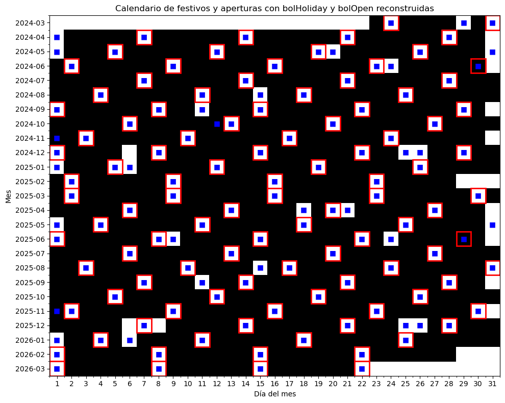

```python
# Calendario de festividades y aperturas de la tienda con bolOpen y bolHoliday reconstruidas
calendario_aperturas: pd.DataFrame = dataset_reconstruido.groupby("idSecuencia").agg({
    "año_mes": "first",
    "dia": "first",
    "bolOpen_reconstruido": "first",
    "dia_semana_str": "first",
    "bolHoliday_reconstruido": "first"
})

datos: pd.DataFrame = calendario_aperturas.pivot(
    index="año_mes",
    columns="dia",
    values="bolOpen_reconstruido"
).fillna(0)

fig, ax = plt.subplots(figsize=(10, 8))
cmap: ListedColormap = ListedColormap(["white", "black"])

im = ax.imshow(datos.values, cmap=cmap, aspect="auto")

ax.set_xticks(np.arange(datos.shape[1]))
ax.set_yticks(np.arange(datos.shape[0]))

ax.set_xticklabels(datos.columns)
ax.set_yticklabels(datos.index)

ax.set_xlabel("Día del mes")
ax.set_ylabel("Mes")
ax.set_title("Calendario de festivos y aperturas con bolHoliday y bolOpen reconstruidas")

ax.set_xticks(np.arange(-.5, datos.shape[1], 1), minor=True)
ax.set_yticks(np.arange(-.5, datos.shape[0], 1), minor=True)

# Se marcan los domingos en rojo
domingos: pd.DataFrame = calendario_aperturas[calendario_aperturas["dia_semana_str"] == "Domingo"]

for _, row in domingos.iterrows():
    fila: int = list(datos.index).index(row["año_mes"])
    col: int = list(datos.columns).index(row["dia"])

    ax.add_patch(plt.Rectangle(
        (col - 0.5, fila - 0.5),
        1, 1,
        fill=False,
        edgecolor="red",
        linewidth=2
    ))

# Se añaden las festividades con un cuadrado azul
festividades: pd.DataFrame = calendario_aperturas[calendario_aperturas["bolHoliday_reconstruido"] == 1]

for _, row in festividades.iterrows():
    fila: int = list(datos.index).index(row["año_mes"])
    col: int = list(datos.columns).index(row["dia"])

    ax.text(
        col, fila,
        "■",
        ha="center",
        va="center",
        color="blue",
        fontsize=10
    )

plt.tight_layout()
plt.show()
```

El calendario ajustado refleja todas las festividades que la empresa ha celebrado durante el año del que se dispone información, así como los días que no se abrió la tienda. Este análisis extenso permite poder utilizar las variable *bolHoliday_reconstruido* y *bolOpen_reconstruido* en los modelos manteniendo la coherencia de los datos ya que, de no haber hecho nada, estos dos atributos hubieran tenido un impacto negativo en la capacidad predictiva de los modelos de aprendizaje automático. Nautralmente esto no es deseable, pero en este caso especialmente ya que estos dos campos aportan un contexto muy rico y amplio para entender la variación de la demanda a lo largo del año.